# Introduction to R and Rstudio

# Variables in this case are characters and logical (TRUE/FALSE)

#Merge two dataframes based in a pattern # We will use the series names to merge these dataframes as this is what they have in common

```r
data.frame.large<-merge(my.data.frame, my.data.frame.2, by="row.names") # "by" indicates the column used for merging
```

#Useful commands to work with tables or dataframes

```r
getwd() # get working directory
```

```
[1] "/Users/anderkkr/Library/CloudStorage/OneDrive-UniversitetetiOslo/00_Master_projects_OD/21_undervisning/2024/UNIS/01_github/UNIS_AB332_2024/Introduction_to_R"
```

You can change the working directory:

```r
#setwd("path/to/my/directory") # set working directory
```

```
#my.table<-read.table(file="table.tsv", sep="\t", header=T) # read table; several other options available
dim(my.table) # Table dimensions
nrow(my.table) # Number of rows
ncol(my.table) # Number of columns
colnames(my.table) # Name of columns
rownames(my.table) # Name of rows
colSums(my.table) # Sum of numeric values in columns
rowSums(my.table) # Sum of numeric values in rows
head(my.table) # See table header
t(my.table) # Transpose table
```

Table subsetting Format: `my.table[row, column]`

```
my.table[1,2] #Get value from row 1, column 2
my.table[1,]  #Get values from row 1 across all columns
my.table$column.name<-NULL #Remove column
my.table[-5,-2] # Remove row 5 and column 2
my.table[-(5:10),] # Remove rows 5 to 10, keep all columns
my.table[,-(which(colSums(my.table)==0))] # Remove columns that sum 0
```

# Installing packages

R has a large repository of packages for different applications

```
install.packages("vegan") # Installs the community ecology package Vegan with hundreds of functions
library("vegan") # load Vegan
```

#Plotting

```r
data("mtcars") # We load a dataset that comes with R
```

The data was extracted from the 1974 Motor Trend US magazine, and comprises fuel consumption and 10 aspects of automobile design and performance for 32 automobiles (1973–74 models).

```
#Data structure
#                      mpg cyl  disp  hp drat    wt  qsec vs am gear carb
# Mazda RX4           21.0   6 160.0 110 3.90 2.620 16.46  0  1    4    4
# Mazda RX4 Wag       21.0   6 160.0 110 3.90 2.875 17.02  0  1    4    4
# Datsun 710          22.8   4 108.0  93 3.85 2.320 18.61  1  1    4    1
# Hornet 4 Drive      21.4   6 258.0 110 3.08 3.215 19.44  1  0    3    1
# ...

# [, 1] mpg Miles/(US) gallon
# [, 2] cyl Number of cylinders
# [, 3] disp    Displacement (cu.in.)
# [, 4] hp  Gross horsepower
# [, 5] drat    Rear axle ratio
# [, 6] wt  Weight (1000 lbs)
# [, 7] qsec    1/4 mile time
# [, 8] vs  Engine (0 = V-shaped, 1 = straight)
# [, 9] am  Transmission (0 = automatic, 1 = manual)
# [,10] gear    Number of forward gears
# [,11] carb    Number of carburetors
```

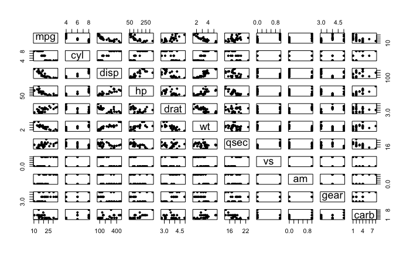

```r
#boxplot(mtcars) # make a boxplot of variables across car models

plot(mtcars, pch=19, cex=0.6) # make x-y plots for all variables
```

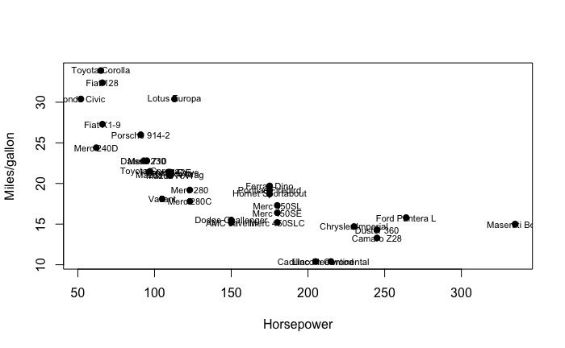

```r
plot(mtcars$hp, mtcars$mpg, xlab="Horsepower", ylab="Miles/gallon", pch=19) # we plot horsepower vs. miles per gallon
text(mtcars$hp, mtcars$mpg, row.names(mtcars), cex=0.7) # we add the car model
```

```r
plot(mtcars$hp, mtcars$mpg, xlab="Horsepower", ylab="Miles/gallon", pch=19, col=ifelse(mtcars$mpg<20,"red", "green")) # We color dots according to a condition (20<x<20 mpg)
text(mtcars$hp, mtcars$mpg, row.names(mtcars), cex=0.7) # we add the car model
```

[figure not shown]

```r
abline(h=20, col="brown") # add a line to the plot
```

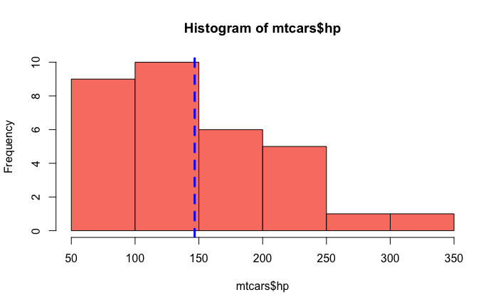

```r
hist(mtcars$hp, col="salmon")
abline(v=mean(mtcars$hp), col="blue", lwd=3, lty=2)
```

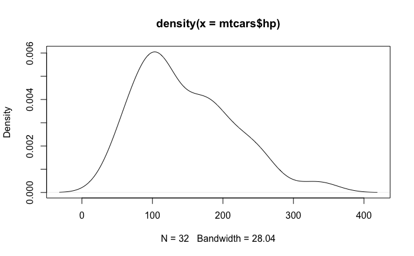

```r
plot(density(mtcars$hp))
```

```r
brands<-c("Mazda", "Mazda","Datsun", "Hornet", "Hornet", "Valiant", "Duster", "Merc", "Merc", "Merc", "Merc", "Merc","Merc","Merc","Cadillac","Lincoln","Chrysler","Fiat",
          "Honda", "Toyota", "Toyota","Dodge","AMC","Camaro","Pontiac", "Fiat","Porsche", "Lotus", "Ford","Ferrari", "Maseratti","Volvo")
mtcars$brand<-brands # we add an extra column with brands
mtcars[1:5,] # let's check
```

|  | mpg | cyl | disp | hp | drat | wt | qsec | vs | am | gear | carb | brand |
| --- | --- | --- | --- | --- | --- | --- | --- | --- | --- | --- | --- | --- |
| Mazda RX4 | 21.0 | 6 | 160 | 110 | 3.90 | 2.620 | 16.46 | 0 | 1 | 4 | 4 | Mazda |
| Mazda RX4 Wag | 21.0 | 6 | 160 | 110 | 3.90 | 2.875 | 17.02 | 0 | 1 | 4 | 4 | Mazda |
| Datsun 710 | 22.8 | 4 | 108 | 93 | 3.85 | 2.320 | 18.61 | 1 | 1 | 4 | 1 | Datsun |
| Hornet 4 Drive | 21.4 | 6 | 258 | 110 | 3.08 | 3.215 | 19.44 | 1 | 0 | 3 | 1 | Hornet |
| Hornet Sportabout | 18.7 | 8 | 360 | 175 | 3.15 | 3.440 | 17.02 | 0 | 0 | 3 | 2 | Hornet |

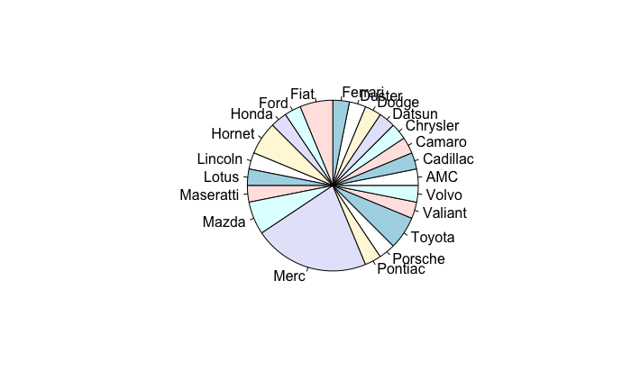

```r
pie(table(mtcars$brand)) # we make a piechart of the brands
```

> For plotting the package ggplot2 is very becomming increasingly popular: It is already included in the package **tidyverse**, but can also be installed by itself:

```r
#install.packages("ggplot2")
library(ggplot2)
```

# Some tips and hits

Use “?” before any function to get the help page.

```r
?sum
```

If you don’t know where a function is from use “??”:

```r
??rarefy
```